# Data612 - Project 1

Abdelmalek Hajjam

6/10/2020

```r
library(randomNames)
library(tidyverse)
library(kableExtra)
library(knitr)
```

```r
# randomly create a toy square matrix with n users and items, ranking 1 to 5

# set simulation vars
set.seed(12345)
n <- 10
percentNAs <- .18
probs <- c(1-percentNAs, percentNAs)

#use randomNames package to get names of persons randomly (which choose male from middle eastern ethnicity)
pnames <- randomNames(10, gender=0, ethnicity=6, which.names="first")
users <- c(pnames)

#could not find a package that can do random type of objects, so I created mine

items <- c("Oud For Greatness","Rasasi La Yuqawam","Halfeti Perfume","Raghba","Armani Prive Oud","ESTEE LAUDER","Club De Nuit","Dehn El Oud Malaki","Baccarat Rouge","Shaghaf Oud")

# generate data
myData <- as.data.frame(replicate(n, floor(runif(n, 1,6))))

myData <- as.data.frame(
    lapply(myData, function(df) df[sample(c(TRUE, NA), prob = probs, size = length(df), replace = TRUE) ]),
    row.names = users,
    col.names = items)

myData %>% kable(caption = "Arabic Perfumes and Colognes Ratings") %>% kable_styling("striped", full_width = TRUE)
```

Arabic Perfumes and Colognes Ratings

|  | Oud.For.Greatness | Rasasi.La.Yuqawam | Halfeti.Perfume | Raghba | Armani.Prive.Oud | ESTEE.LAUDER | Club.De.Nuit | Dehn.El.Oud.Malaki | Baccarat.Rouge | Shaghaf.Oud |
| --- | --- | --- | --- | --- | --- | --- | --- | --- | --- | --- |
| Fayyaad | 3 | 4 | 4 | NA | 4 | NA | 5 | 5 | 2 | 4 |
| Jameel | 2 | 1 | 3 | 5 | 2 | 3 | 3 | NA | NA | 2 |
| Kaarim | 5 | 1 | 5 | 2 | NA | 2 | 1 | 1 | 5 | 4 |
| Naseer | 4 | 4 | 4 | 2 | 4 | 2 | 1 | 4 | 4 | 2 |
| Arafaat | 4 | NA | 2 | 4 | 5 | 1 | NA | NA | 3 | NA |
| Jumail | 2 | NA | NA | 3 | 2 | 4 | 2 | 3 | 5 | 5 |
| Awad | NA | 5 | NA | 4 | NA | 5 | 5 | 4 | 4 | 5 |
| Abdul Qayyoom | 3 | 5 | 1 | 1 | 1 | NA | NA | 4 | 5 | 3 |
| Rida | 2 | 4 | NA | NA | NA | 3 | 5 | 1 | 2 | 1 |
| Zaaid | 3 | 1 | 4 | 2 | 5 | NA | 1 | 2 | 2 | 2 |

#### Break your ratings into separate training and test datasets

```r
training_portion <- sample(n, size = floor(n * 0.75), replace=F)

training.data <- myData[training_portion, ]
testing.data <- myData[-training_portion, ]

training.data %>% kable(caption = "Training Dataset") %>% kable_styling("striped", full_width = TRUE)
```

Training Dataset

|  | Oud.For.Greatness | Rasasi.La.Yuqawam | Halfeti.Perfume | Raghba | Armani.Prive.Oud | ESTEE.LAUDER | Club.De.Nuit | Dehn.El.Oud.Malaki | Baccarat.Rouge | Shaghaf.Oud |
| --- | --- | --- | --- | --- | --- | --- | --- | --- | --- | --- |
| Awad | NA | 5 | NA | 4 | NA | 5 | 5 | 4 | 4 | 5 |
| Arafaat | 4 | NA | 2 | 4 | 5 | 1 | NA | NA | 3 | NA |
| Jumail | 2 | NA | NA | 3 | 2 | 4 | 2 | 3 | 5 | 5 |
| Kaarim | 5 | 1 | 5 | 2 | NA | 2 | 1 | 1 | 5 | 4 |
| Zaaid | 3 | 1 | 4 | 2 | 5 | NA | 1 | 2 | 2 | 2 |
| Naseer | 4 | 4 | 4 | 2 | 4 | 2 | 1 | 4 | 4 | 2 |
| Jameel | 2 | 1 | 3 | 5 | 2 | 3 | 3 | NA | NA | 2 |

```r
testing.data %>% kable(caption = "Testing Dataset") %>% kable_styling("striped", full_width = TRUE)
```

Testing Dataset

|  | Oud.For.Greatness | Rasasi.La.Yuqawam | Halfeti.Perfume | Raghba | Armani.Prive.Oud | ESTEE.LAUDER | Club.De.Nuit | Dehn.El.Oud.Malaki | Baccarat.Rouge | Shaghaf.Oud |
| --- | --- | --- | --- | --- | --- | --- | --- | --- | --- | --- |
| Fayyaad | 3 | 4 | 4 | NA | 4 | NA | 5 | 5 | 2 | 4 |
| Abdul Qayyoom | 3 | 5 | 1 | 1 | 1 | NA | NA | 4 | 5 | 3 |
| Rida | 2 | 4 | NA | NA | NA | 3 | 5 | 1 | 2 | 1 |

#### Calculate the raw average (mean) rating for every user-item combination

```r
# raw average rating (training set)
raw_avg_train <- mean(as.matrix(training.data), na.rm=TRUE)
raw_avg_train
```

```
## [1] 3.105263
```

#### Calculate the RMSE for raw average for both your training data and your test data

```r
RMSE <- function(observed, predicted) {
    # get RMSE
    sqrt(mean((observed - predicted)^2, na.rm=TRUE))
}

# the RMSE for raw average for training set
RMSE_training.data <- RMSE(as.matrix(training.data), raw_avg_train)
RMSE_training.data
```

```
## [1] 1.385187
```

```r
# the RMSE for raw average for test set
RMSE_testing.data <- RMSE(as.matrix(testing.data), raw_avg_train)
RMSE_testing.data
```

```
## [1] 1.453979
```

#### calculate the bias for each user and each item

```r
user_bias_training <- rowMeans(as.matrix(training.data), na.rm = T) - raw_avg_train
user_bias_testing <- rowMeans(as.matrix(testing.data), na.rm = T) - raw_avg_train
item_bias_training <- colMeans(as.matrix(training.data), na.rm = T) - raw_avg_train

user_bias_training %>% kable(caption = "User Bias Training") %>% kable_styling("striped", full_width = TRUE)
```

User Bias Training

|  | x |
| --- | --- |
| Awad | 1.4661654 |
| Arafaat | 0.0614035 |
| Jumail | 0.1447368 |
| Kaarim | -0.2163743 |
| Zaaid | -0.6608187 |
| Naseer | -0.0052632 |
| Jameel | -0.4802632 |

```r
item_bias_training %>% kable(caption = "Item Bias Training") %>% kable_styling("striped", full_width = TRUE)
```

Item Bias Training

|  | x |
| --- | --- |
| Oud.For.Greatness | 0.2280702 |
| Rasasi.La.Yuqawam | -0.7052632 |
| Halfeti.Perfume | 0.4947368 |
| Raghba | 0.0375940 |
| Armani.Prive.Oud | 0.4947368 |
| ESTEE.LAUDER | -0.2719298 |
| Club.De.Nuit | -0.9385965 |
| Dehn.El.Oud.Malaki | -0.3052632 |
| Baccarat.Rouge | 0.7280702 |
| Shaghaf.Oud | 0.2280702 |

```r
user_bias_testing %>% kable(caption = "Item Bias Testing") %>% kable_styling("striped", full_width = TRUE)
```

|  | x |
| --- | --- |
| Fayyaad | 0.7697368 |
| Abdul Qayyoom | -0.2302632 |
| Rida | -0.5338346 |

#### Calculate the baseline predictors for every user-item combination.

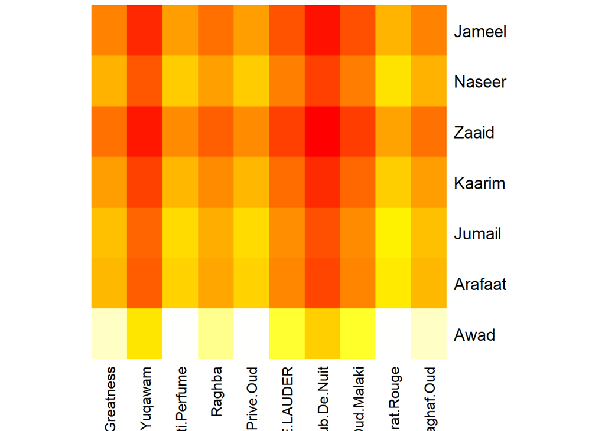

```r
baseline_predictor <- function(rawAvg, userBias, itemBias) {
    # calculates predictions based on rawaverage and user and item bias calcs
    userlist <- names(userBias)
    itemlist <- names(itemBias)
    df <- data.frame()

    for (i in userBias) {
        UserPred <- rawAvg + i + itemBias
        df <- rbind(df, UserPred)
    }

    # Like the videos lectures suggests, we should not exceed our max and min values
    df[df > 5] <- 5
    df[df < 1] <- 1

    row.names(df) <- userlist
    names(df) <- itemlist
    df
}

training_Predictions <- baseline_predictor(raw_avg_train, user_bias_training, item_bias_training)
heatmap(as.matrix(training_Predictions), Rowv=NA, Colv=NA, scale = 'none', col = heat.colors(256))
```

```r
training_Predictions %>% kable(caption = "Training Predictions") %>% kable_styling("striped", full_width = TRUE)
```

Training Predictions

|  | Oud.For.Greatness | Rasasi.La.Yuqawam | Halfeti.Perfume | Raghba | Armani.Prive.Oud | ESTEE.LAUDER | Club.De.Nuit | Dehn.El.Oud.Malaki | Baccarat.Rouge | Shaghaf.Oud |
| --- | --- | --- | --- | --- | --- | --- | --- | --- | --- | --- |
| Awad | 4.799499 | 3.866165 | 5.000000 | 4.609023 | 5.000000 | 4.299499 | 3.632832 | 4.266165 | 5.000000 | 4.799499 |
| Arafaat | 3.394737 | 2.461403 | 3.661404 | 3.204261 | 3.661404 | 2.894737 | 2.228070 | 2.861404 | 3.894737 | 3.394737 |
| Jumail | 3.478070 | 2.544737 | 3.744737 | 3.287594 | 3.744737 | 2.978070 | 2.311403 | 2.944737 | 3.978070 | 3.478070 |
| Kaarim | 3.116959 | 2.183626 | 3.383626 | 2.926483 | 3.383626 | 2.616959 | 1.950292 | 2.583626 | 3.616959 | 3.116959 |
| Zaaid | 2.672515 | 1.739181 | 2.939181 | 2.482038 | 2.939181 | 2.172515 | 1.505848 | 2.139181 | 3.172515 | 2.672515 |
| Naseer | 3.328070 | 2.394737 | 3.594737 | 3.137594 | 3.594737 | 2.828070 | 2.161404 | 2.794737 | 3.828070 | 3.328070 |
| Jameel | 2.853070 | 1.919737 | 3.119737 | 2.662594 | 3.119737 | 2.353070 | 1.686403 | 2.319737 | 3.353070 | 2.853070 |

```r
testing_Predictions <- baseline_predictor(raw_avg_train, user_bias_testing, item_bias_training)
testing_Predictions %>% kable(caption = "Testing Predictions") %>% kable_styling("striped", full_width = TRUE)
```

Testing Predictions

|  | Oud.For.Greatness | Rasasi.La.Yuqawam | Halfeti.Perfume | Raghba | Armani.Prive.Oud | ESTEE.LAUDER | Club.De.Nuit | Dehn.El.Oud.Malaki | Baccarat.Rouge | Shaghaf.Oud |
| --- | --- | --- | --- | --- | --- | --- | --- | --- | --- | --- |
| Fayyaad | 4.103070 | 3.169737 | 4.369737 | 3.912594 | 4.369737 | 3.603070 | 2.936403 | 3.569737 | 4.603070 | 4.103070 |
| Abdul Qayyoom | 3.103070 | 2.169737 | 3.369737 | 2.912594 | 3.369737 | 2.603070 | 1.936403 | 2.569737 | 3.603070 | 3.103070 |
| Rida | 2.799499 | 1.866165 | 3.066165 | 2.609023 | 3.066165 | 2.299499 | 1.632832 | 2.266165 | 3.299499 | 2.799499 |

#### Calculate the RMSE for the baseline predictors for both your training data and your test data.

```r
# the RMSE for the baseline predictors for training set
RMSE_training_Predictions <- RMSE(as.matrix(training.data), as.matrix(training_Predictions))
RMSE_training_Predictions
```

```
## [1] 1.102288
```

```r
# the RMSE for the baseline predictors for test data
RMSE_testing_Predictions <- RMSE(as.matrix(testing.data), as.matrix(testing_Predictions))
RMSE_testing_Predictions
```

```
## [1] 1.69063
```

#### Summarizing results

```r
trainVec <- c(RMSE_training.data,
              RMSE_training_Predictions,
              (1-RMSE_training_Predictions/RMSE_training.data)*100)
testVec <- c(RMSE_testing.data,
             RMSE_testing_Predictions,
             (1-RMSE_testing_Predictions/RMSE_testing.data)*100)
summary <- data.frame(trainVec, testVec)
names(summary) <- c("Training", "Testing")
row.names(summary) <- c("Raw Average RMSE",
                       "Simple Predictor RMSE",
                       "Percent Improvement")

summary %>% kable(caption = "Summary") %>% kable_styling("striped", full_width = TRUE)
```

Summary

|  | Training | Testing |
| --- | --- | --- |
| Raw Average RMSE | 1.385187 | 1.453979 |
| Simple Predictor RMSE | 1.102288 | 1.690630 |
| Percent Improvement | 20.423168 | -16.276060 |

RMSE is lower for the baseline predictor compared to raw average predictor for the Training data set. 20% improvement on the Training data set. For the Testing data set, we’ve got no improvement. This is due to the fact that the test data set being randomly generated and has no inherent biases and therefore the training biases for items applied to the testing set did not improve performance. On the other hand, these same bias are fit for the training set, hence will clearly improve the RMSE for the training set.